# RNA-seq Data Preprocessing: GSE173955

Yue Chen

2025 Feb 11

# **1. Introduction**

This notebook preprocesses RNA-seq expression data from the **GSE173955** dataset, sourced from **GEO**. The dataset investigates gene expression in **postmortem brain tissues** from **Alzheimer’s Disease (AD) patients and healthy controls**.

# **2. Data Acquisition**

## **2.1 Install & Load Required Libraries**

```r
if (!requireNamespace("BiocManager", quietly = TRUE)) install.packages("BiocManager")
BiocManager::install(c("GEOquery", "org.Hs.eg.db", "AnnotationDbi", "edgeR", "readxl"))
library(GEOquery)
library(org.Hs.eg.db)
library(AnnotationDbi)
library(edgeR)
library(readxl)
```

## **2.2 Download Expression Data from GEO**

This step was done using the code in Lecture 4.

```r
data_set_geoid <- "GSE173955"
gse <- getGEO(data_set_geoid, GSEMatrix=FALSE)
```

[output not shown]

[output not shown]

[output not shown]

[output not shown]

[output not shown]

[output not shown]

[output not shown]

[output not shown]

[output not shown]

[output not shown]

[output not shown]

[output not shown]

[output not shown]

[output not shown]

[output not shown]

[output not shown]

[output not shown]

[output not shown]

[output not shown]

[output not shown]

[output not shown]

[output not shown]

```r
sfilenames <- getGEOSuppFiles(data_set_geoid, fetch_files = FALSE)
data_filename <- sfilenames$fname[2]

download_dir <- file.path(getwd())
missing_files <- sfilenames$fname[!unlist(
  lapply(sfilenames$fname, function(x) file.exists(file.path(download_dir, data_set_geoid, x))))]

if (length(missing_files) > 0) {
  for (i in 1:length(missing_files)) {
    getGEOSuppFiles(data_set_geoid, filter_regex = missing_files[i], baseDir = download_dir, fetch_files = TRUE)
  }
}
```

## **2.4 Load Data**

```r
ad_data <- read_excel(file.path(download_dir, data_set_geoid, data_filename), sheet = 1)
```

# **3. Data Cleaning & Mapping to HUGO Symbols**

## **3.1 Rename Columns**

Rename the columns to unwrap the data set

```r
colnames(ad_data) <- c("Transcript_ID", paste0("AD_Sample_", 1:9), "Mean_AD", "SD_AD",
                        paste0("Non_AD_Sample_", 1:9), "Mean_Non_AD", "SD_Non_AD",
                        "log2_FC", "Avg_abundance_log2CPM", "Likelihood_Ratio", "P_value", "FDR",
                        "Chromosome", "Location_Start", "Location_End", "Gene_Symbol", "RefSeq_ID")
# Delete the original column names
ad_data <- ad_data[-c(1, 2), ]
```

## **3.2 Map Gene Symbols**

Since the Gene Symbols column is already in HUGO format, I only need to check whether it’s complete or not.

```r
# Check if all gene symbols exist
sum(is.na(ad_data$Gene_Symbol))
```

```
## [1] 0
```

# **4. Outlier Detection & Removal**

## **4.1 Identify Outliers Using 3-SD Rule**

Because the value in ad_data is not numeric, they need to be converted into numeric first.

```r
ad_data[, grep("AD_Sample|Non_AD_Sample", names(ad_data))] <-
  lapply(ad_data[, grep("AD_Sample|Non_AD_Sample", names(ad_data))], as.numeric)
ad_cols <- grep("^AD_Sample", colnames(ad_data), value = TRUE)
non_ad_cols <- grep("Non_AD_Sample", colnames(ad_data), value = TRUE)
expression_cols <- c(ad_cols, non_ad_cols)

outliers <- apply(ad_data[, expression_cols], 2, function(x) {
  x > mean(x, na.rm=TRUE) + 3 * sd(x, na.rm=TRUE) |
    x < mean(x, na.rm=TRUE) - 3 * sd(x, na.rm=TRUE)
})

total_outliers <- sum(outliers, na.rm=TRUE)
total_outliers
```

```
## [1] 639
```

## **4.2 Remove Outliers**

```r
genes_with_outliers <- rowSums(outliers) > 0
ad_data_filtered <- ad_data[!genes_with_outliers, ]
```

# **5. Normalization**

## **5.1 Convert Data to Numeric & Create DGEList**

```r
dge <- DGEList(counts = as.matrix(ad_data[, grep("AD_Sample", names(ad_data))]))
```

## **5.2 Apply CPM Normalization**

```r
# I set this value to be 9 because there are 18 samples in total
# Get rid off the very small value
keep_lax <- rowSums(cpm(dge)>1) >9
n_data <- cpm(dge, log = TRUE)
n_data <- n_data[!keep_lax,]
```

# **6. Data Visualization**

## **6.1 Boxplot Before & After Normalization**

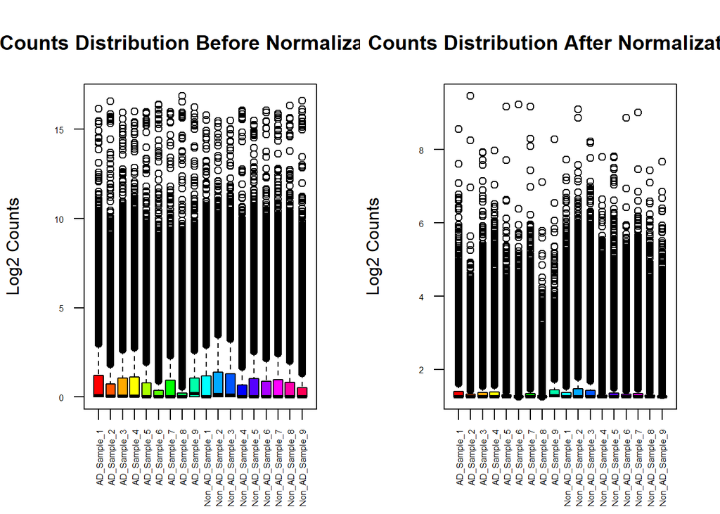

```r
par(mfrow=c(1,2))
# Align the reading to a log base
log_raw_counts <- log2(dge$counts + 1)
colors <- rainbow(ncol(log_raw_counts))
boxplot(log_raw_counts, las=2, col=rainbow(ncol(dge$counts)),
        main="Counts Distribution Before Normalization", ylab="Log2 Counts",
        cex.axis=0.5)
boxplot(n_data, las=2, col=rainbow(ncol(dge$counts)),
        main="Counts Distribution After Normalization", ylab="Log2 Counts",
        cex.axis=0.5)
```

```r
par(mfrow=c(1,1))
```